# ad1_vm_3

Dr. Víctor Manuel García Guerrero

vmgarcia@colmex.mx

[figure not shown]

[figure not shown]

[figure not shown]

## Índice

- Proceso de decremento múltiple
- Funciones de decremento de múltiple
- Tabla de mortalidad
- Matemáticas asociadas
  - Fórmula de Greville-Chang
  - Fuerza de mortalidad-de-i
  - Probabilidad de supervivencia
  - Tablas-de-causa-eliminada

# Proceso de decremento múltiple

Un proceso de decremento múltiple es uno en el que se tiene mas de un modo de salir de un estado definido. En ocasiones, estos son llamados como **riesgos de competencia**.

- **Análisis de fertilidad**: cuando se considera que las personas están expuestas al riesgo de embarazo y a la interrupción del uso de anticonceptivos.
- **Migración**: cuando los individuos están expuestos al riesgo de trasladarse a diferentes lugares.
- **Nupcialidad**: cuando las personas casadas están expuestas a los riesgos de divorcio y viudez.

# Funciones de decremento de múltiple

**Notación**

- ${}_nd^i_x$: número de decrementos por la causa **i** entre las edades **x** y **x+n**
- ${}_nq^i_x$: probabilidad de que ocurra el decremento por la causa **i** entre las edades **x** y **x+n**.
- ${}_nm^i_x$: tasa específica de decremento por la causa **i** entre las edades **x** y **x+n**.
- $l^i_x$: número de personas que alcanzan la edad **x** y que eventualmente sucumben por la causa **i**
- ${}_nq^i_x = \frac{{}_nd_x^i}{l_x}$
- ${}_nm^i_x = \frac{{}_nd_x^i}{{}_nL_x}$
- $l_x^i = \sum_{a=x}^{\omega^+} {}_nd_a^i$

# Funciones de decremento de múltiple

- ${}_nd_x=\sum_{i=1}^N {}_nd_x^i$
- ${}_nm_x = \sum_{i=1}^N \frac{{}_nd_x^i}{{}_nL_x}=\frac{\sum_{i=1}^N {}_nd_x^i}{{}_nL_x}=\frac{{}_nd_x}{{}_nL_x}$
- ${}_nq_x = \frac{{}_nd_x}{l_x}=\sum_{i=1}^N \frac{{}_nd_x^i}{l_x}=\sum_{i=1}^N{}_nq_x^i$
- $\sum_{i=1}^N l_x^i = \sum_{i=1}^N \sum_{a=x}^{\omega^+} {}_nd_a^i=\sum_{a=x}^{\omega^+} \sum_{i=1}^N {}_nd_a^i = \sum_{a=x}^{\omega^+} {}_nd_a = l_x$

# Tabla de mortalidad

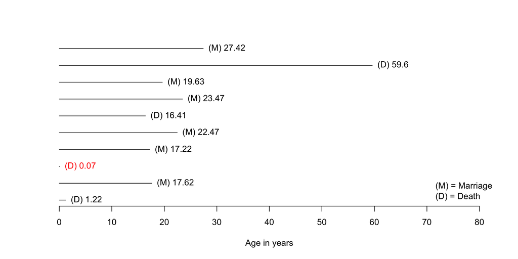

| $x$ | $l_x$ | ${}_nd_x^D$ | ${}_nd_x^M$ | ${}_nd_x$ | ${}_nq_x^D$ | ${}_nq_x^M$ | ${}_nq_x$ | $l_x^D$ | $l_x^M$ |  |
| --- | --- | --- | --- | --- | --- | --- | --- | --- | --- | --- |
| 0 | 10 | 1 | 0 | 1 | 1/10 | 0 | 1/10 | 4 | 6 |  |

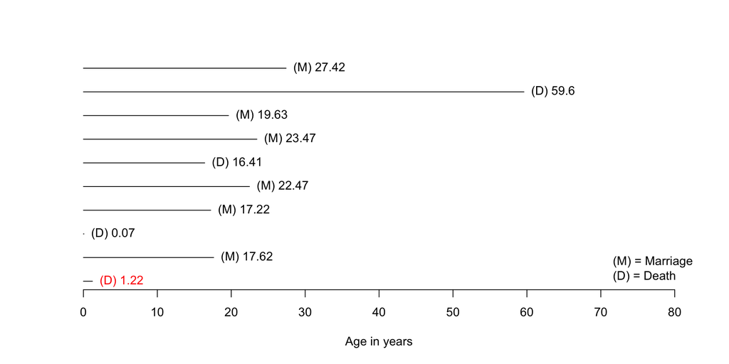

| $x$ | $l_x$ | ${}_nd_x^D$ | ${}_nd_x^M$ | ${}_nd_x$ | ${}_nq_x^D$ | ${}_nq_x^M$ | ${}_nq_x$ | $l_x^D$ | $l_x^M$ |  |
| --- | --- | --- | --- | --- | --- | --- | --- | --- | --- | --- |
| 0 | 10 | 1 | 0 | 1 | 1/10 | 0 | 1/10 | 4 | 6 |  |
| 1 | 9 | 1 | 0 | 1 | 1/9 | 0 | 1/9 | 3 | 6 |  |

| $x$ | $l_x$ | ${}_nd_x^D$ | ${}_nd_x^M$ | ${}_nd_x$ | ${}_nq_x^D$ | ${}_nq_x^M$ | ${}_nq_x$ | $l_x^D$ | $l_x^M$ |  |
| --- | --- | --- | --- | --- | --- | --- | --- | --- | --- | --- |
| 0 | 10 | 1 | 0 | 1 | 1/10 | 0 | 1/10 | 4 | 6 |  |
| 1 | 9 | 1 | 0 | 1 | 1/9 | 0 | 1/9 | 3 | 6 |  |
| 5 | 8 | 0 | 0 | 0 | 0 | 0 | 0 | 3 | 6 |  |

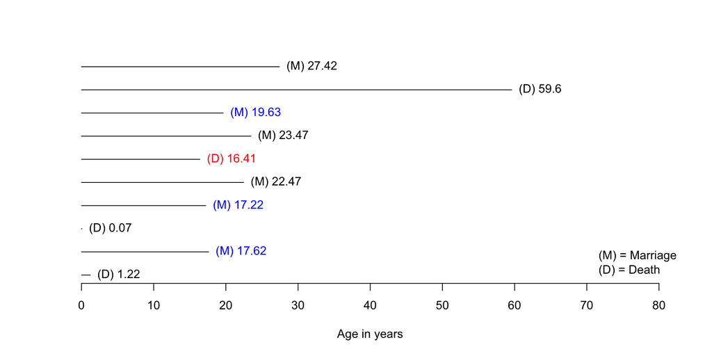

| $x$ | $l_x$ | ${}_nd_x^D$ | ${}_nd_x^M$ | ${}_nd_x$ | ${}_nq_x^D$ | ${}_nq_x^M$ | ${}_nq_x$ | $l_x^D$ | $l_x^M$ |  |
| --- | --- | --- | --- | --- | --- | --- | --- | --- | --- | --- |
| 0 | 10 | 1 | 0 | 1 | 1/10 | 0 | 1/10 | 4 | 6 |  |
| 1 | 9 | 1 | 0 | 1 | 1/9 | 0 | 1/9 | 3 | 6 |  |
| 5 | 8 | 0 | 0 | 0 | 0 | 0 | 0 | 3 | 6 |  |
| 10 | 8 | 1 | 3 | 4 | 1/8 | 3/8 | 1/2 | 2 | 6 |  |

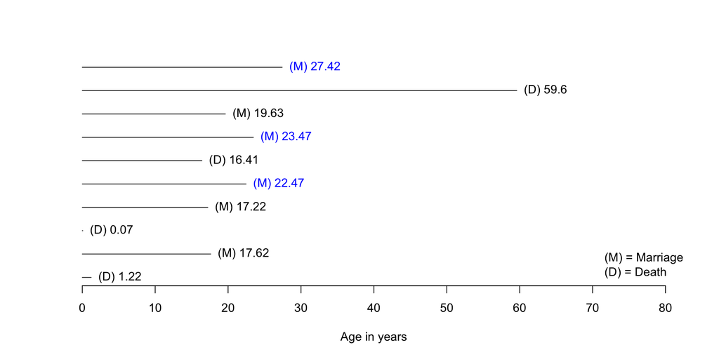

| $x$ | $l_x$ | ${}_nd_x^D$ | ${}_nd_x^M$ | ${}_nd_x$ | ${}_nq_x^D$ | ${}_nq_x^M$ | ${}_nq_x$ | $l_x^D$ | $l_x^M$ |  |
| --- | --- | --- | --- | --- | --- | --- | --- | --- | --- | --- |
| 0 | 10 | 1 | 0 | 1 | 1/10 | 0 | 1/10 | 4 | 6 |  |
| 1 | 9 | 1 | 0 | 1 | 1/9 | 0 | 1/9 | 3 | 6 |  |
| 5 | 8 | 0 | 0 | 0 | 0 | 0 | 0 | 3 | 6 |  |
| 10 | 8 | 1 | 3 | 4 | 1/8 | 3/8 | 1/2 | 2 | 6 |  |
| 20 | 4 | 0 | 3 | 3 | 0 | 3/4 | 3/4 | 1 | 3 |  |

| $x$ | $l_x$ | ${}_nd_x^D$ | ${}_nd_x^M$ | ${}_nd_x$ | ${}_nq_x^D$ | ${}_nq_x^M$ | ${}_nq_x$ | $l_x^D$ | $l_x^M$ |  |
| --- | --- | --- | --- | --- | --- | --- | --- | --- | --- | --- |
| 0 | 10 | 1 | 0 | 1 | 1/10 | 0 | 1/10 | 4 | 6 |  |
| 1 | 9 | 1 | 0 | 1 | 1/9 | 0 | 1/9 | 3 | 6 |  |
| 5 | 8 | 0 | 0 | 0 | 0 | 0 | 0 | 3 | 6 |  |
| 10 | 8 | 1 | 3 | 4 | 1/8 | 3/8 | 1/2 | 2 | 6 |  |
| 20 | 4 | 0 | 3 | 3 | 0 | 3/4 | 3/4 | 1 | 3 |  |
| 30 | 1 | 0 | 0 | 0 | 0 | 0 | 0 | 1 | 0 |  |
| 40 | 1 | 0 | 0 | 0 | 0 | 0 | 0 | 1 | 0 |  |

[output not shown]

Índice

# Matemáticas asociadas

**`Fórmula de Greville-Chang`**

${}_nq^i _x = \frac{n.{}_nm^i_x}{1+(n-{}_na_x){}_nm_x}$

**Nota**

Los valores de ${}_nm_x$ y ${}_na_x$ en el denominador no son específicos de la causa i , sino que son valores correspondientes a todas las causas de disminución combinadas.

# Matemáticas asociadas

$\require{cancel}$

$\frac{{}_nq^i _x}{{}_nq _x}= \frac{\frac{n.{}_nm^i_x}{1+(n-{}_na_x){}_nm_x}}{\frac{n.{}_nm_x}{1+(n-{}_na_x){}_nm_x}}$

$=\frac{\frac{n.{}_nm^i_x}{\cancel{1+(n-{}_na_x){}_nm_x}}}{\frac{n.{}_nm_x}{\cancel{1+(n-{}_na_x){}_nm_x}}}$

$=\frac{{}_nm^i_x}{{}_nm_x}$

$=\frac{\frac{{}_ad^i_x}{{}_nL_x}}{\frac{{}_ad_x}{{}_nL_x}}$

# Matemáticas asociadas

$=\frac{\frac{{}_ad^i_x}{\cancel{{}_nL_x}}}{\frac{{}_ad_x}{\cancel{{}_nL_x}}}$

$=\frac{{}_nd^i_x}{{}_nd_x}$

$\approx\frac{{}_nD^i_x}{{}_nD_x}$

**Nota**

${}_nD^i_x$ Defunciones observadas de las causa i

# Matemáticas asociadas

$=\frac{\frac{{}_ad^i_x}{\cancel{{}_nL_x}}}{\frac{{}_ad_x}{\cancel{{}_nL_x}}}$

$=\frac{{}_nd^i_x}{{}_nd_x}$

$\approx\frac{{}_nD^i_x}{{}_nD_x}$

$\color{green}{\Rightarrow {}_nq^i_x={}_nq_x\frac{{}_nD^i_x}{{}_nD_x}}$

Índice

# Matemáticas asociadas

**`Fuerza de mortalidad de i`**

$\mu(x)=\displaystyle\lim_{n\to 0}{}_nm_x$

$\mu^i(x)=\displaystyle\lim_{n\to 0}{}_nm^i_x$

${}_nm_x=\color{red}{\displaystyle\sum_{i=1}^N {}_nm^i_x}$

**Aditividad de los limites**

$\displaystyle\lim_{n\to0}(a_n+b_n)=\displaystyle\lim_{n\to0}a_n+\displaystyle\lim_{n\to0}b_n$

$N$ es el número de decrementos

Índice

# Matemáticas asociadas

**`Probabilidad de supervivencia`**

${}_np_x = \frac{l(x+n)}{l(x)}=\displaystyle\frac{l(y)e^{-\int_{a}^{x+n}\mu(y)dy}}{l(y)e^{-\int_{a}^{x}\mu(y)dy}}$

$=\displaystyle\frac{e^{-\int_{a}^{x+n}\mu(y)dy}}{e^{-\int_{a}^{x}\mu(y)dy}}$

# Matemáticas asociadas

${}_np_x = \frac{l(x+n)}{l(x)}=\displaystyle\frac{l(y)e^{-\int_{a}^{x+n}\mu(y)dy}}{l(y)e^{-\int_{a}^{x}\mu(y)dy}}$

$=\displaystyle\frac{e^{-\int_{a}^{x+n}\mu(y)dy}}{e^{-\int_{a}^{x}\mu(y)dy}}$

$=\color{red}{\displaystyle e^{-\int_{x}^{x+n}\mu(y)dy}}$

**El diablo está en los detalles**

# Matemáticas asociadas

${}_np_x = \frac{l(x+n)}{l(x)}=\displaystyle\frac{l(y)e^{-\int_{a}^{x+n}\mu(y)dy}}{l(y)e^{-\int_{a}^{x}\mu(y)dy}}$

$=\displaystyle\frac{e^{-\int_{a}^{x+n}\mu(y)dy}}{e^{-\int_{a}^{x}\mu(y)dy}}$

$= e^{-\int_{x}^{x+n}\mu(y)dy}$

$= e^{-\displaystyle\int_{x}^{x+n}\displaystyle\sum_{i=i}^N\mu^i(y)dy}$

$= e^{-\displaystyle\sum_{i=i}^N\int_{x}^{x+n}\displaystyle\mu^i(y)dy}$

# Matemáticas asociadas

$\color{red}{= e^{-\displaystyle\sum_{i=i}^N\int_{x}^{x+n}\displaystyle\mu^i(y)dy}}$

**El diablo está en los detalles**

- **Aditividad de la integral:** si $f(x)+g(x)\Rightarrow \int_a^b[f(x)+g(x)]dx=\int_a^bf(x)dx+\int_a^bg(x)dx$
- $\displaystyle\sum_{i=i}^N f_i(x)= f_1(x)+f_2(x)+\dots+f_N(x)$

# Matemáticas asociadas

$= e^{-\displaystyle\sum_{i=i}^N\int_{x}^{x+n}\displaystyle\mu^i(y)dy}$

**El diablo está en los detalles**

$\displaystyle\prod_{i=1}^N e^{f_i(x)}=e^{f_1(x)}e^{f_2(x)}\dots e^{f_N(x)}$

# Matemáticas asociadas

$= e^{-\displaystyle\sum_{i=i}^N\int_{x}^{x+n}\displaystyle\mu^i(y)dy}$

$= \displaystyle\prod_{i=1}^N {}_n^*p^i_x$

Índice

# Matemáticas asociadas

**Tablas de causa eliminada**

${}_nd_x = l(x) \int_x^{x+n} e^{-\int_x^a \mu(y) \, dy} \, \mu(a) \, da$

${}_n^* d_x^i = {}^* l^i(x) \int_x^{x+n} e^{-\int_x^a \mu^i(y) \, dy} \, \mu^i(a) \, da$

${}_nd_x^i = l(x) \int_x^{x+n} e^{-\int_x^a \mu(y) \, dy} \, \mu^i(a) \, da$

**Nota**

${}^*f^i$ función de causa eliminada por la causa **i**

# Matemáticas asociadas

${}^*_nm^i_x=\frac{{}^*_nd^i_x}{{}^*_nL^i_x}\,\,\,$ ${}_nm^i_x=\frac{{}_nd^i_x}{{}_nL^i_x}$

${}_nm_x^i = \frac{\int_x^{x+n} e^{-\int_x^a \mu(y) \, dy} \, \mu^i(a) \, da}{\int_x^{x+n} e^{-\int_x^a \mu(y) \, dy} \, da}$

${}_n^* m_x^i = \frac{\int_x^{x+n} e^{-\int_x^a \mu^i(y) \, dy} \, \mu^i(a) \, da}{\int_x^{x+n} e^{-\int_x^a \mu^i(y) \, dy} \, da}$

# Matemáticas asociadas

$\mu^i(x)=R^i\mu(x)$

$\mu(x)=\displaystyle\sum_{i=1}^N \mu^i(x)=\sum_{i=1}^N R^i\mu(x)=\mu(x)\sum_{i=1}^N R^i$

$\Rightarrow\displaystyle\sum_{i=1}^N R^i=1$

# Matemáticas asociadas

${}_n^*p^i_x = e^{-\int_x^{x+n}\mu^i(a)da}$

$=e^{-\int_x^{x+n}R^i\mu(a)da}$

$=e^{-R^i[\int_x^{x+n}\mu(a)da]}$

$=\left[e^{\int_x^{x+n}\mu(a)da}\right]^{R^i}$

$={}_np_x^{R^i}$

# Matemáticas asociadas

$R^i= \frac{{}_nD^i_x}{{}_nD_x}$

$R^{-i} = \frac{{}_nD_x-{}_nD^i_x}{{}_nD_x}=1-\frac{{}_nD^i_x}{{}_nD_x}$

**Nota**

$R^i$ proporcion de personas que mueren por la causa i

$R^{-i}$ proporcion de personas que no sucumen por la causa i

# Matemáticas asociadas

${}^*_nL^i_x = {}^*_nl^i_x + {}^*_na^i_x . {}^*_nd^i_x$

${}^*_na^i_x = \frac{-\frac{n}{24}{}^*_nd^i_x+\frac{n}{2}{}^*_nd^i_x+\frac{n}{24}{}^*_nd^i_x}{{}^*_nd^i_x}$

${}^*T^i_x = \displaystyle\sum_{a=x}^{\omega+}{}^*_nL^i_a$

${}^*e^i_x = \frac{{}^*T^i_x}{{}^*l^i_x}$

**Nota**

${}^*_nL^i_x$ años persona vividos de individuos que perecen por la causa i

${}^*_na^i_x=n+R^i\frac{{}_nq_x}{{}^*_nq_x}({}_na_x-n)$

para edades intermedias

${}^*_na^i_{\omega+}=\frac{e_{\omega^+}}{R^i}$